# Playing with Oceanographic Data

Thomas Bryce Kelly

2020-05-08

```r
library(TheSource)
## Load in the data from BCO-DMO
# Note: the unit line is the second row, so to get the header values and the data we have to use two read operations.
data = read.csv('https://erddap.bco-dmo.org/erddap/tabledap/bcodmo_dataset_668083.csv', stringsAsFactors = F, skip = 2, header = F)
colnames(data) = read.csv('https://erddap.bco-dmo.org/erddap/tabledap/bcodmo_dataset_668083.csv', stringsAsFactors = F, nrows = 1, header = F)
```

First, we will plot a map of the stations so we can make sense of where they are.

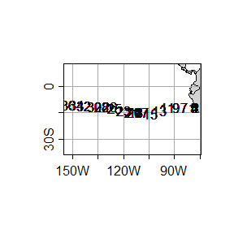

```r
map = make.map(lon.min = min(data$longitude), lon.max = max(data$longitude),
               lat.min = min(data$latitude), lat.max = max(data$latitude))
add.map.text(data$longitude, data$lat, data$STNNBR)
```

Let’s plot a section using stations >=7

```r
l = which(data$STNNBR >= 7)

section = build.section(x = data$longitude[l],
                        y = data$DEPTH_MAX[l],
                        z = data$Y_SPT_CONC_PUMP[l],
                        lat = data$latitude[l],
                        lon = data$longitude[l], field.names = 'Yttrium', x.factor = 50)
```

```
## No gridder specified, defaulting to gridIDW. Other options: gridNN, gridNNI and gridKrige.
```

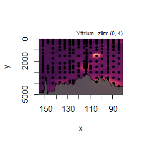

```r
plot.section(section, mark.points = T, ylim = c(5000, 0), zlim = c(0,4))
add.section.bathy(section, bathy.col = '#555555e0')
```

How about a higher resolution interpolation?

```r
l = which(data$STNNBR >= 7)

section = build.section(x = data$longitude[l],
                        y = data$DEPTH_MAX[l],
                        z = data$Y_SPT_CONC_PUMP[l],
                        lat = data$latitude[l],
                        lon = data$longitude[l], field.names = 'Yttrium',
                        x.scale = 0.2, y.scale = 10,
                        x.factor = 50)
```

```
## No gridder specified, defaulting to gridIDW. Other options: gridNN, gridNNI and gridKrige.
```

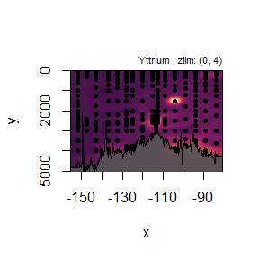

```r
plot.section(section, mark.points = T, ylim = c(5000, 0), zlim = c(0, 4))
add.section.bathy(section, bathy.col = '#555555e0')
```

And let’s add a color bar:

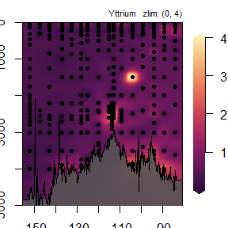

```r
par(plt = c(0.1, 0.8, 0.1, 0.9))
plot.section(section, mark.points = T, ylim = c(5000, 0), zlim = c(0, 4))
add.section.bathy(section, bathy.col = '#555555e0')
add.colorbar(min = 0, max = 4, labels = c(1:4), pal = ocean.matter)
```

```r
l = which(data$STNNBR >= 7)

section.idw = build.section(x = data$longitude[l],
                        y = data$DEPTH_MAX[l],
                        z = data$Y_SPT_CONC_PUMP[l],
                        lat = data$latitude[l],
                        lon = data$longitude[l], field.names = 'Yttrium',
                        nx = 100, ny = 100,
                        x.factor = 50)
```

```
## No gridder specified, defaulting to gridIDW. Other options: gridNN, gridNNI and gridKrige.
```

```r
section.NN = build.section(x = data$longitude[l],
                        y = data$DEPTH_MAX[l],
                        z = data$Y_SPT_CONC_PUMP[l],
                        lat = data$latitude[l],
                        lon = data$longitude[l], field.names = 'Yttrium',
                        nx = 100, ny = 100,
                        x.factor = 50, gridder = gridNN)
section.NNI = build.section(x = data$longitude[l],
                        y = data$DEPTH_MAX[l],
                        z = data$Y_SPT_CONC_PUMP[l],
                        lat = data$latitude[l],
                        lon = data$longitude[l], field.names = 'Yttrium',
                        nx = 100, ny = 100,
                        x.factor = 50, gridder = gridNNI)
section.krige = build.section(x = data$longitude[l],
                        y = data$DEPTH_MAX[l],
                        z = data$Y_SPT_CONC_PUMP[l],
                        lat = data$latitude[l],
                        lon = data$longitude[l], field.names = 'Yttrium',
                        nx = 100, ny = 100,
                        x.factor = 50, gridder = gridKrig)
```

```
##           coordinates         z
## 111 (-5637.517, 2200) 0.3613128
## 112  (-5637.517, 600) 0.3796334
## 205   (-6400.033, 20) 2.0841268
## 275 (-7599.976, 2400) 0.3098531
## 120 (-5637.517, 2200) 0.3797003
## 127  (-5637.517, 600) 0.4547515
## 213   (-6400.033, 20) 0.9608959
## 284 (-7599.976, 2400) 0.4177608
## [using ordinary kriging]
```

Let’s take a look at how the various gridding products compare graphically. The **kriging** product does a good job of minimizing the influence of the concentration peak around 1500m. Unfortunately, this peak also corresponds to a low-sampling resolution region in the data overall as seen in the **nearest neighbor** interpolation (the peak corresponds to a large polygon rather than a small one). This has a direct impact on the **natural neighbor** interpolation. The **inverse distance** interpolation falls somewhere between these two more extreme treatments of that peak with smooth transitions and a more limited zone of influence (compared to the **NNI**).

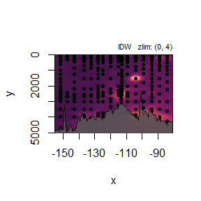

```r
## Standard IDW
plot.section(section.idw, mark.points = T, ylim = c(5000, 0), main = 'IDW', zlim = c(0, 4))
add.section.bathy(section.idw, bathy.col = '#555555e0')
```

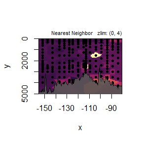

```r
## NN
plot.section(section.NN, mark.points = T, ylim = c(5000, 0), main = 'Nearest Neighbor', zlim = c(0, 4))
add.section.bathy(section.NN, bathy.col = '#555555e0')
```

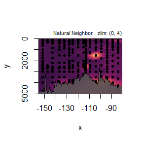

```r
## NNI
plot.section(section.NNI, mark.points = T, ylim = c(5000, 0), main = 'Natural Neighbor', zlim = c(0, 4))
add.section.bathy(section.NNI, bathy.col = '#555555e0')
```

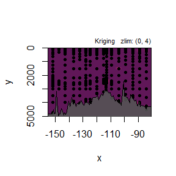

```r
## Krige
plot.section(section.krige, mark.points = T, ylim = c(5000, 0), main = 'Kriging', zlim = c(0, 4))
add.section.bathy(section.krige, bathy.col = '#555555e0')
```

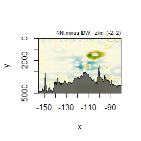

```r
section.idw$grid$NNI.minus.IDW = section.NNI$grid$Yttrium - section.idw$grid$Yttrium

plot.section(section.idw, field = 'NNI.minus.IDW', ylim = c(5000, 0), zlim = c(-2, 2), pal = ocean.delta)
add.section.bathy(section.idw, bathy.col = '#555555e0')
```